# Act Report

## Analyzation and Visualization Task 2

My second analyzation task was centered around seeing which dog 'stage' tweets had the most retweets and see if that was consistent with the results of task 1. What I found was that 'pupper' was the most retweeted stage, but it was closely followed by 'doggo'. In task 1 we saw that 'pupper' was the most common 'stage' label by more than double, but here we see that the retweet counts are much closer in value between the highest rank and second highest rank, 'pupper' and 'doggo' respectively. The different stages rank in the same order but the distance between 'pupper' and 'doggo' is dramatically closer in comparison with inital 'stage' tweets.

```python
# create dataframes containing only dogs in that 'stage'

pupper_df = dog_stages_df.loc[dog_stages_df['stage'] == 'pupper']
doggo_df = dog_stages_df.loc[dog_stages_df['stage'] == 'doggo']
puppo_df = dog_stages_df.loc[dog_stages_df['stage'] == 'puppo']
floofer_df = dog_stages_df.loc[dog_stages_df['stage'] == 'floofer']
```

```python
# obtain the sum of retweets for each dataframe/dog 'stage'

pupper_retweets = sum(pupper_df['retweet_count'])
doggo_retweets = sum(doggo_df['retweet_count'])
puppo_retweets = sum(puppo_df['retweet_count'])
floofer_retweets = sum(floofer_df['retweet_count'])
```

```python
# inspect the values and ensure they are still in int format (we had to change them from float earlier)
pupper_retweets, doggo_retweets, puppo_retweets, floofer_retweets
```

```
(514673, 448919, 161623, 38214)
```

```python
# create a dictionary with the 'stage' as the key and the summed values obtained in the previous cell as the values

retweets_dict = {'Pupper': pupper_retweets, 'Doggo': doggo_retweets, 'Puppo': puppo_retweets, 'Floofer': floofer_retweets}
```

```python
# turn the dictionary into a pandas series/dataframe

retweets_totals_df = pd.Series(retweets_dict)
```

```python
# reset the index of the new series/dataframe for graphing purposes

retweets_totals_df.reset_index()
```

|  | index | 0 |
| --- | --- | --- |
| 0 | Pupper | 514673 |
| 1 | Doggo | 448919 |
| 2 | Puppo | 161623 |
| 3 | Floofer | 38214 |

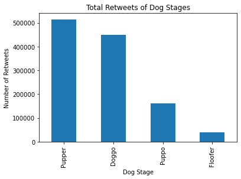

```python
#graph the dataframe

retweets_totals_df.plot(kind='bar', y =0);
plt.title('Total Retweets of Dog Stages')
plt.xlabel('Dog Stage')
plt.ylabel('Number of Retweets');
```

## Analyzation and Visualization Task 3

```python
# create a list of all numerator values from our master dataframe (as all denominator values are 10 and we can assume every rating is 'over ten'
# or 'x/10'
numerators_list = twitter_archive_master.rating_numerator.value_counts()
```

```python
# turn the newly created value_counts list into a dataframe

numerators_list_df = pd.DataFrame(numerators_list)
```

```python
# reset the index so the rating values can be used easily as an axis

numerators_list_df.reset_index(inplace=True)
```

```python
# check newly created df

numerators_list_df
```

|  | index | rating_numerator |
| --- | --- | --- |
| 0 | 12 | 450 |
| 1 | 10 | 419 |
| 2 | 11 | 396 |
| 3 | 13 | 261 |
| 4 | 9 | 150 |
| 5 | 8 | 95 |
| 6 | 7 | 51 |
| 7 | 14 | 35 |
| 8 | 5 | 33 |
| 9 | 6 | 32 |
| 10 | 3 | 19 |
| 11 | 4 | 15 |
| 12 | 2 | 9 |
| 13 | 1 | 4 |

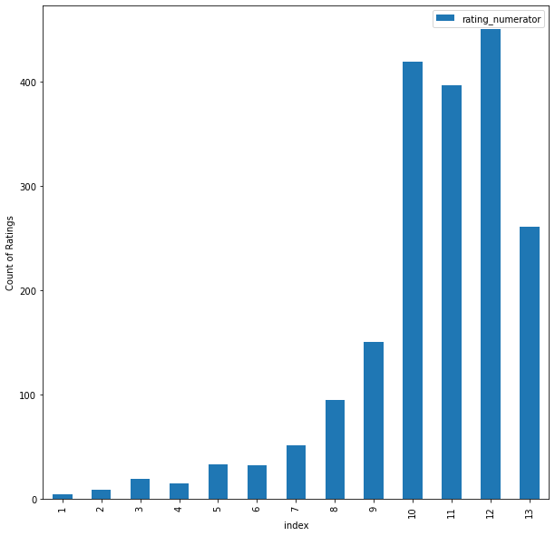

```python
# graph the data frame with the numerator_values in sequential order so we can see the distribution of values

field = 'index'
numerator_values = [1,2,3,4,5,6,7,8,9,10,11,12,13]
ax = numerators_list_df.set_index(field).loc[numerator_values].plot(kind='bar', figsize=(10,10))
ax.set_ylabel('Count of Ratings')
```